# Evolutionary Genomics & Bioinformatics

Gulalai Shah

9/7/2020

Hello Dr. Blanchard! I learned a lot by taking your class, I didn’t have any prior coding experience and you made the process easily understandable. Thank you for always being available to help (and oftentimes staying longer than you had to). I hope you have a safe and enjoyable break :)

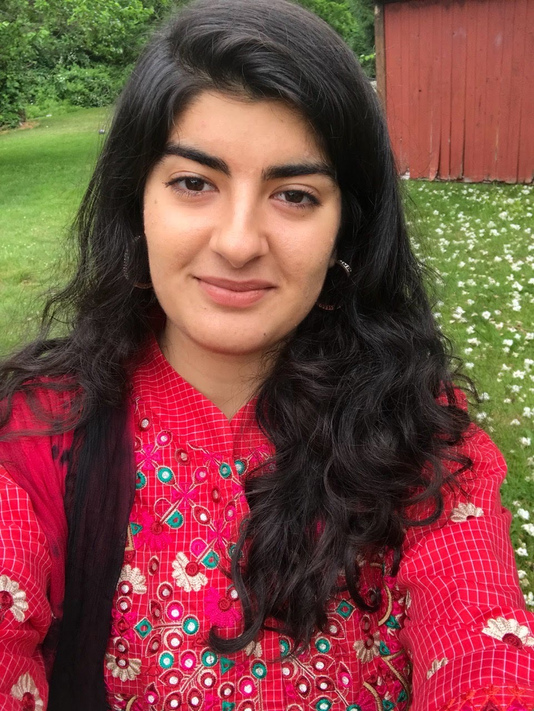

## Labs

- Lab 1: Introduction to R and Reproducible Research
- Lab 2: git, GitHub and Rstudio projectsFile
- Lab 3A: Starting with the Data
- Lab 3B: Manipulating Data
- Lab 4: Data wrangling and graphing COVID-19 reporting data (Part 1)
- Lab 4A: Data Wrangling and Graphing COVID-19 Reporting Data, Part 2
- Lab 5: Data wrangling and graphing COVID-19 reporting data (Part 2)
- Lab 5x: Interactive Graphs and Animations
- Lab 6: Mapping COVID-19 reporting data
- Lab 7: Working on the command line
- Lab 8: Sequence Alignment, Phylogenetic Analysis and Tree Visualization
- Lab 9: Programming in R - Regular Expressions
- Lab 9x: Programming in R - Control Structures and Functions
- Lab 10: Population genomics based on high throughput sequencing (HTS)
- Lab 11: Microbiome Analysis using dada2 and phyloseq
- Lab 12: Network Analysis using Cytoscape and RCy3
- Lab 13: Sprucing up your Rmarkdown and GitHub Page